# Trends

## Introduction

Model $Y_t = \mu_t + X_t$

- $\mu_t$ = trend
- $X_t$ = random error

If $E(X_t) = 0$ (zero mean process), then $E(Y_t) = E(\mu_t + X_t) = \mu_t$

## Common Models

**Linear**

Increasing/Decreasing at a constant rate.

$$\mu_t = \beta_0 + \beta_1t$$

**Quadratic**
$$\mu_t = \beta_0 + \beta_1t + \beta_2t^2$$$

……and so on for higher order models

**Cycles**

Use sin and cos functions to model trends with periodicity

$\mu_t = \beta_0 + \sum(\alpha; cos\omega; t + \beta_jsin\omega_j; t)$

Another way to remove a trend is a method called differencing. This is simply taking differences such as:

$Y_t - Y_{t-1}$

Consider $Y_t = \mu + X_t$. The trend is the constant $\mu$. Often $\bar{Y} = \frac{1}{n}\sum_{i=1}^n Y_i$ is an estimator for $\mu$.

*Formula 2.2.7 in the book*

$Var(\bar{Y}) = Var(\frac{1}{n}y_1 + \frac{1}{n}y_2 + ... + \frac{1}{n}y_n)$ $Var(\bar{Y}) = \frac{1}{n^2}\sum_{t=1}^n Var(Y_i) + 2\sum_{t=2}^n\sum_{j=1}^{t-1} c_tc_j\gamma_{t,j}$

$= \frac{1}{n^2}[n\gamma_o] + \frac{2}{n^2}[\gamma_{2,1} + \gamma_{3,1} + \gamma_{3,2} + \gamma_{4,1} + \gamma_{4,2} + \gamma_{4,3} +... + \gamma_{n,n-1}]$

*Note:* $\gamma_o = Var(Y_t)$ $\gamma_{t,t}= \gamma_{j,j} = \gamma_{o}$

## In Class Code Excercises

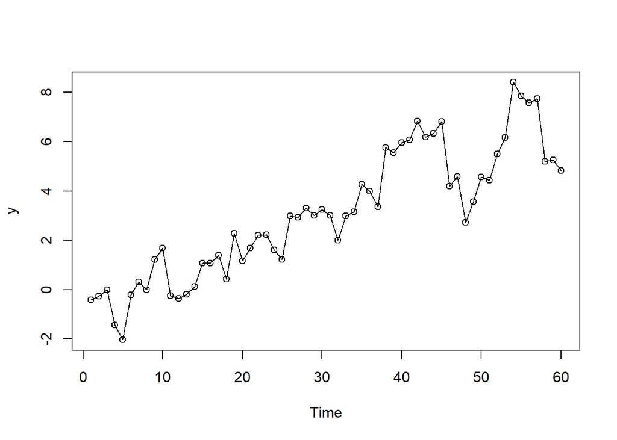

```r
library(tidyverse)
library(TSA)
data(rwalk)
plot(rwalk, type = "o")
```

```r
model1 = lm(rwalk~time(rwalk))
summary(model1)
```

```
##
## Call:
## lm(formula = rwalk ~ time(rwalk))
##
## Residuals:
##      Min       1Q   Median       3Q      Max
## -2.70045 -0.79782  0.06391  0.63064  2.22128
##
## Coefficients:
##              Estimate Std. Error t value Pr(>|t|)
## (Intercept) -1.007888   0.297245  -3.391  0.00126 **
## time(rwalk)  0.134087   0.008475  15.822  < 2e-16 ***
## ---
## Signif. codes:  0 '***' 0.001 '**' 0.01 '*' 0.05 '.' 0.1 ' ' 1
##
## Residual standard error: 1.137 on 58 degrees of freedom
## Multiple R-squared:  0.8119, Adjusted R-squared:  0.8086
## F-statistic: 250.3 on 1 and 58 DF,  p-value: < 2.2e-16
```

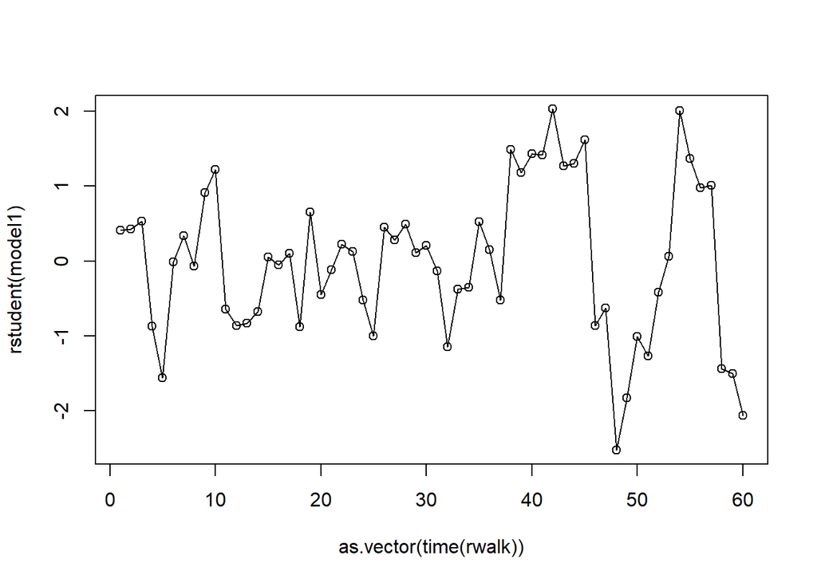

```r
plot(y=rstudent(model1), x=as.vector(time(rwalk)), type="o")
```

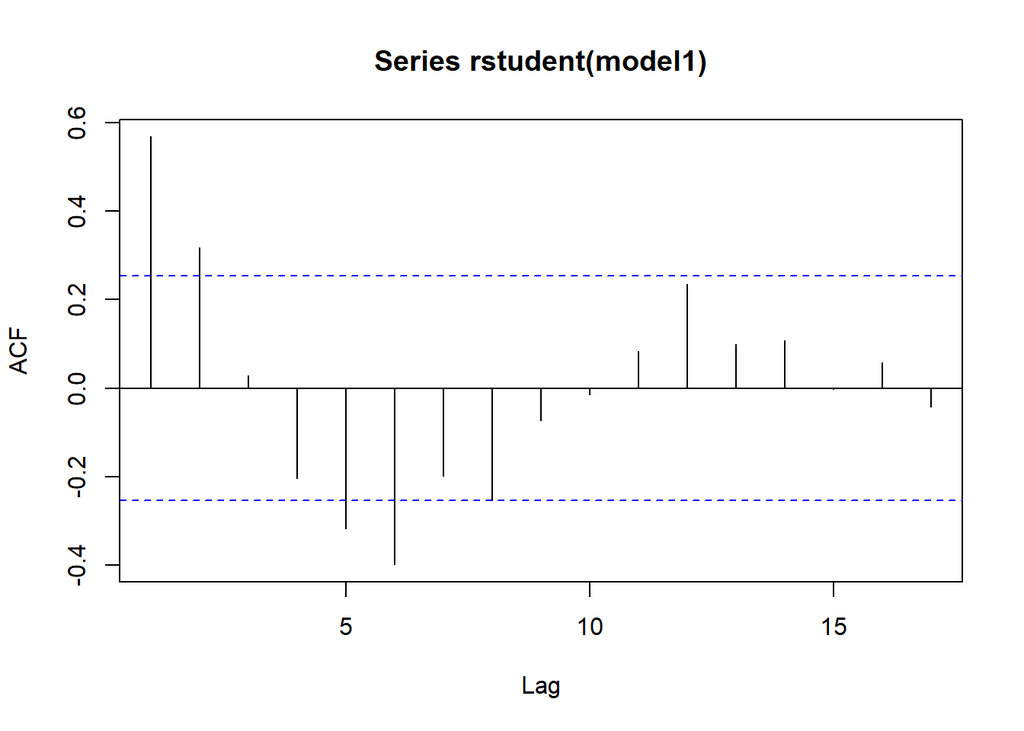

```r
acf(rstudent(model1))
```

```r
# Dubuque, Iowa Temperature Data
data(tempdub)
modeldub=lm(tempdub~time(tempdub))
summary(modeldub)
```

```
##
## Call:
## lm(formula = tempdub ~ time(tempdub))
##
## Residuals:
##     Min      1Q  Median      3Q     Max
## -37.871 -19.066   2.394  17.053  28.156
##
## Coefficients:
##                Estimate Std. Error t value Pr(>|t|)
## (Intercept)   -214.1324   920.7668  -0.233    0.816
## time(tempdub)    0.1322     0.4674   0.283    0.778
##
## Residual standard error: 19.43 on 142 degrees of freedom
## Multiple R-squared:  0.0005629,  Adjusted R-squared:  -0.006475
## F-statistic: 0.07998 on 1 and 142 DF,  p-value: 0.7777
```

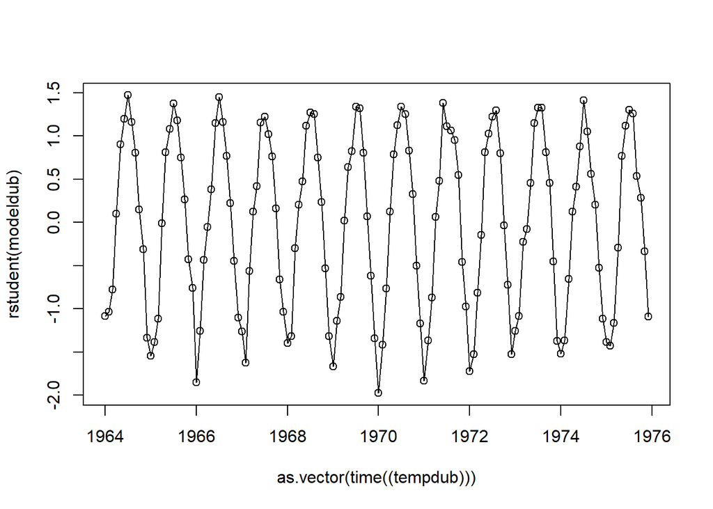

```r
plot(y=rstudent(modeldub), x=as.vector(time((tempdub))), type="o")
```

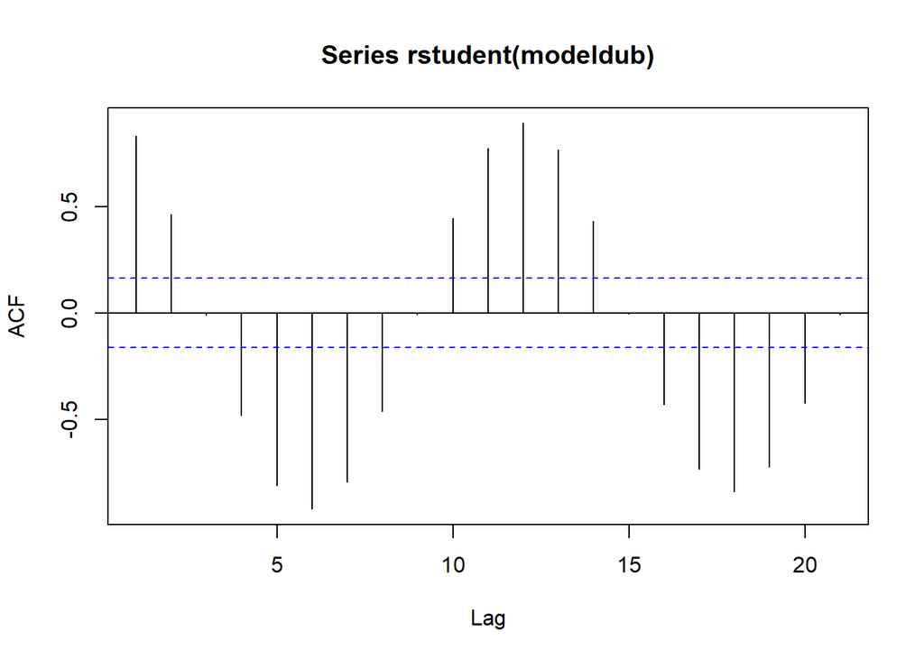

```r
acf(rstudent(modeldub))
```

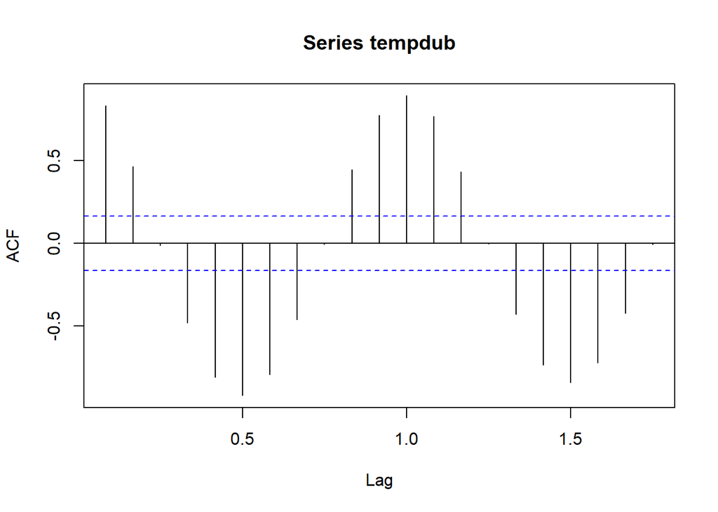

```r
acf(tempdub) # notice the pattern 12 time periods apart
```

```r
# Seasonal Means Model
month.=season(tempdub) # period added to help table display
model2 = lm(tempdub~month.-1) # The -1 removes the intercept
summary(model2)
```

```
##
## Call:
## lm(formula = tempdub ~ month. - 1)
##
## Residuals:
##     Min      1Q  Median      3Q     Max
## -8.2750 -2.2479  0.1125  1.8896  9.8250
##
## Coefficients:
##                 Estimate Std. Error t value Pr(>|t|)
## month.January     16.608      0.987   16.83   <2e-16 ***
## month.February    20.650      0.987   20.92   <2e-16 ***
## month.March       32.475      0.987   32.90   <2e-16 ***
## month.April       46.525      0.987   47.14   <2e-16 ***
## month.May         58.092      0.987   58.86   <2e-16 ***
## month.June        67.500      0.987   68.39   <2e-16 ***
## month.July        71.717      0.987   72.66   <2e-16 ***
## month.August      69.333      0.987   70.25   <2e-16 ***
## month.September   61.025      0.987   61.83   <2e-16 ***
## month.October     50.975      0.987   51.65   <2e-16 ***
## month.November    36.650      0.987   37.13   <2e-16 ***
## month.December    23.642      0.987   23.95   <2e-16 ***
## ---
## Signif. codes:  0 '***' 0.001 '**' 0.01 '*' 0.05 '.' 0.1 ' ' 1
##
## Residual standard error: 3.419 on 132 degrees of freedom
## Multiple R-squared:  0.9957, Adjusted R-squared:  0.9953
## F-statistic:  2569 on 12 and 132 DF,  p-value: < 2.2e-16
```

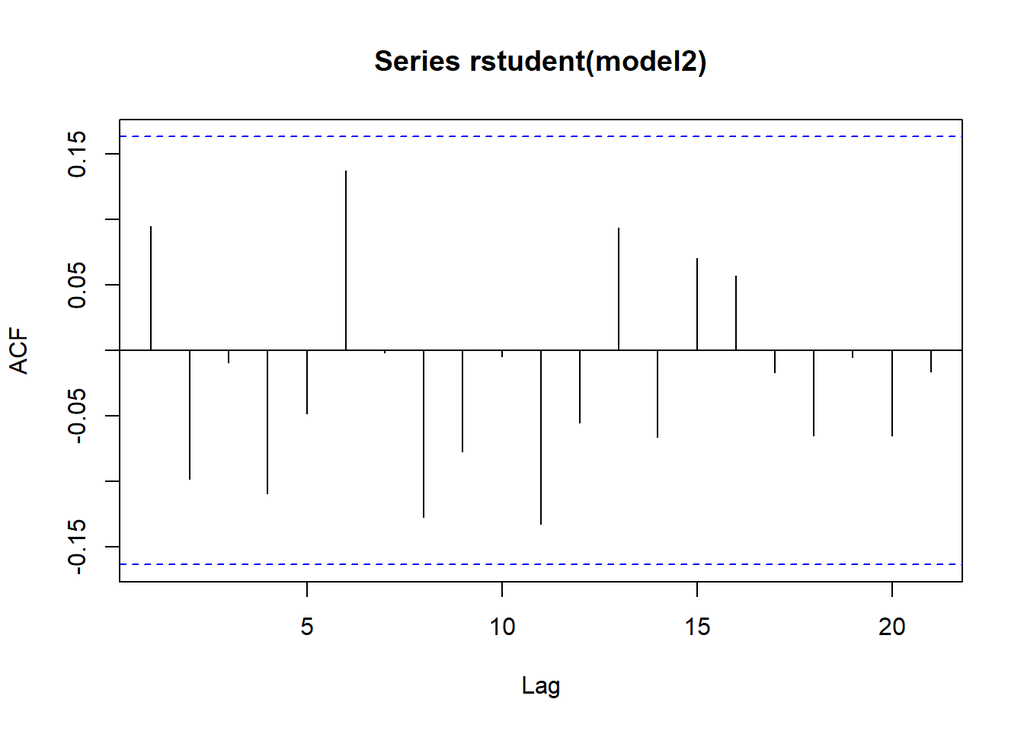

```r
acf(rstudent(model2))
```

```r
# Alternative Fit
model3=lm(tempdub~month.) # January is automatically dropped
summary(model3)
```

```
##
## Call:
## lm(formula = tempdub ~ month.)
##
## Residuals:
##     Min      1Q  Median      3Q     Max
## -8.2750 -2.2479  0.1125  1.8896  9.8250
##
## Coefficients:
##                 Estimate Std. Error t value Pr(>|t|)
## (Intercept)       16.608      0.987  16.828  < 2e-16 ***
## month.February     4.042      1.396   2.896  0.00443 **
## month.March       15.867      1.396  11.368  < 2e-16 ***
## month.April       29.917      1.396  21.434  < 2e-16 ***
## month.May         41.483      1.396  29.721  < 2e-16 ***
## month.June        50.892      1.396  36.461  < 2e-16 ***
## month.July        55.108      1.396  39.482  < 2e-16 ***
## month.August      52.725      1.396  37.775  < 2e-16 ***
## month.September   44.417      1.396  31.822  < 2e-16 ***
## month.October     34.367      1.396  24.622  < 2e-16 ***
## month.November    20.042      1.396  14.359  < 2e-16 ***
## month.December     7.033      1.396   5.039 1.51e-06 ***
## ---
## Signif. codes:  0 '***' 0.001 '**' 0.01 '*' 0.05 '.' 0.1 ' ' 1
##
## Residual standard error: 3.419 on 132 degrees of freedom
## Multiple R-squared:  0.9712, Adjusted R-squared:  0.9688
## F-statistic: 405.1 on 11 and 132 DF,  p-value: < 2.2e-16
```

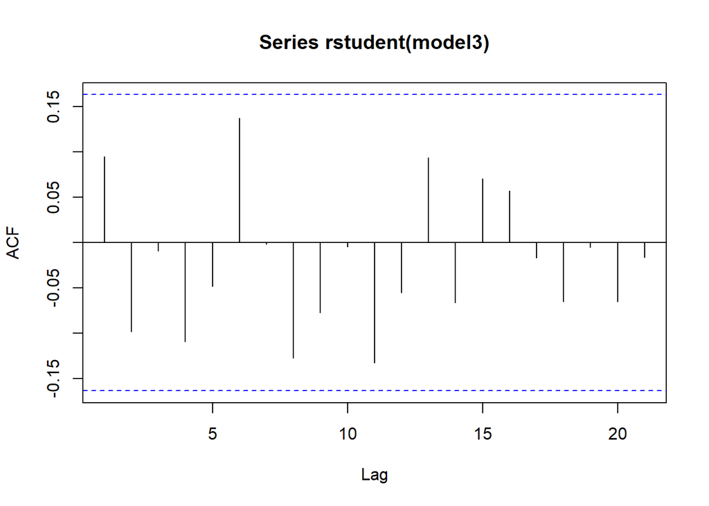

```r
acf(rstudent(model3))
```

For a series $Y_1, Y_2, Y_3, ..., Y_n$:

> $Y_t = \mu_t + X_t$

$\mu_t \rightarrow$ find model that will ignore this term

$X_t \rightarrow$ this is the variable we would like to model

## What is Independence?

Rolling dice example in class

### Stationary Process

Expected Value of Rolling Dice

$$\begin{eqnarray}
E(Y_t) & = & E(r_1 + r_2 + ... + r_t)\\
& = & 4.5t\\
u_t & = & Y_1 - Y_2\\
& = & r_t
\end{eqnarray}$$

Look at differences instead of the expected value

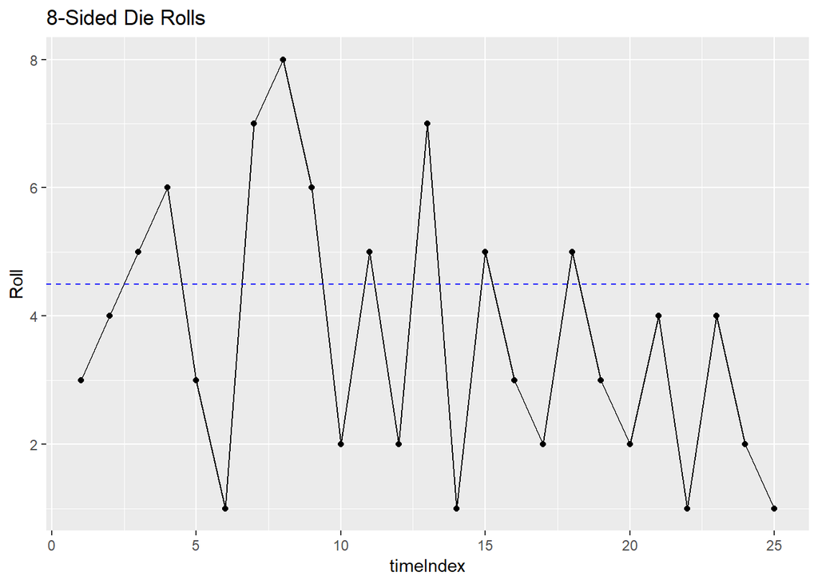

```r
Roll = c(3, 4, 5, 6, 3, 1, 7, 8, 6, 2, 5, 2, 7, 1, 5, 3, 2, 5, 3, 2, 4, 1, 4, 2, 1)
timeIndex = c(1:25)

diceData = tibble(timeIndex, Roll)

dicePlot = ggplot(diceData, aes(x = timeIndex, y = Roll)) +
  geom_point() +
  geom_line() +
  geom_hline(yintercept =  4.5, linetype = "dashed", color = "blue") +
  ggtitle("8-Sided Die Rolls")

plot(dicePlot)
```

```r
library(TSA)
library(kableExtra)

# List of values after rolling dice 25 times
Roll = c(3, 4, 5, 6, 3, 1, 7, 8, 6, 2, 5, 2, 7, 1, 5, 3, 2, 5, 3, 2, 4, 1, 4, 2, 1)

# Force to a data frame to allow as input to kable
runsTest = as.data.frame(runs(Roll, k = 4.5))

# Create a table of the output
kable(runsTest) %>%
  kable_styling(full_width = F) %>%
  add_header_above(header = c("Runs Test" = 6))
```

| Runs Test pvalue | Runs Test observed.runs | Runs Test expected.runs | Runs Test n1 | Runs Test n2 | Runs Test k |
| --- | --- | --- | --- | --- | --- |
| 0.978 | 13 | 12.52 | 16 | 9 | 4.5 |

Consider the random walk from TSA package (Expected Value is 0)

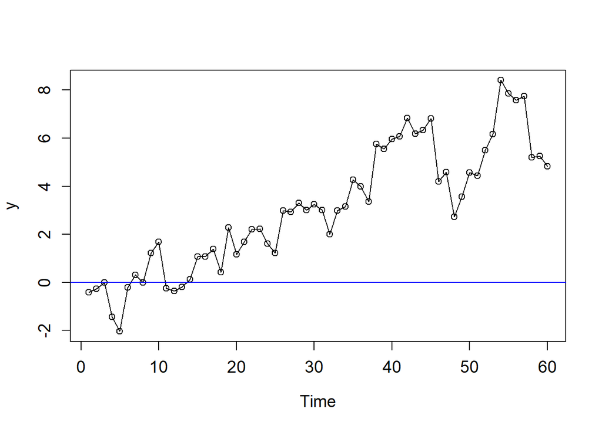

```r
library(TSA)

data(rwalk)
win.graph(12,7,14)
plot.ts(rwalk, type="o")
abline(h=0, col="blue")
```

```r
runs(rwalk)
```

```
## $pvalue
## [1] 2.6e-06
##
## $observed.runs
## [1] 6
##
## $expected.runs
## [1] 17.66667
##
## $n1
## [1] 10
##
## $n2
## [1] 50
##
## $k
## [1] 0
```

## Periodic Functions

$\mu_t \rightarrow$ periodic function

$Y_t = \mu_t + X_t = \beta cos(2\pi ft + \Theta$

$\beta \rightarrow$ amplitude *($\mu_t$ oscillates between $-\beta$ and $\beta$)*

$f \rightarrow$ frequency *($\frac{1}{f}$ is the period)*

$\Theta \rightarrow$ phase shift

### Trigonometry Review

$cos(a + b) = cos(a) + cos(b) - sin(a) + sin(b)$

$\beta cos(2\pi ft + \Theta = \beta[cos(2\pi ft)cos(\Theta) - \beta\sin(2\pi ft)\sin(\Theta)]$

The only random variable in the above equation is $t$. Combining $\beta$ and $cos(\Theta)$:

$\beta_1cos(2\pi ft) - \beta_2sin(2\pi ft)$

$\beta_1 = \beta cos(\Theta)$

$\beta_1 = \frac{\beta}{cos(\Theta)}$

$\beta_2 = -\beta sin(\Theta)$

$\beta_2 = \frac{-\beta}{sin(\Theta)}$

Given these two betas:

$\frac{\beta_1}{cos(\Theta)} = \frac{-\beta}{sin(\Theta)}$

$\frac{sin(\Theta)}{cos(\Theta)} = \frac{-\beta_2}{\beta_1}$

$tan(\Theta) = \frac{-\beta_2}{\beta_1}$

$\Theta = tan^{-1}(\frac{-\beta_2}{\beta_1})$

### Example

Cosine Example from Canvas

```r
library(TSA)
data("tempdub")

har.=harmonic(tempdub,1)
model4tempcos=lm(tempdub~har.)
summary(model4tempcos)
```

```
##
## Call:
## lm(formula = tempdub ~ har.)
##
## Residuals:
##      Min       1Q   Median       3Q      Max
## -11.1580  -2.2756  -0.1457   2.3754  11.2671
##
## Coefficients:
##                 Estimate Std. Error t value Pr(>|t|)
## (Intercept)      46.2660     0.3088 149.816  < 2e-16 ***
## har.cos(2*pi*t) -26.7079     0.4367 -61.154  < 2e-16 ***
## har.sin(2*pi*t)  -2.1697     0.4367  -4.968 1.93e-06 ***
## ---
## Signif. codes:  0 '***' 0.001 '**' 0.01 '*' 0.05 '.' 0.1 ' ' 1
##
## Residual standard error: 3.706 on 141 degrees of freedom
## Multiple R-squared:  0.9639, Adjusted R-squared:  0.9634
## F-statistic:  1882 on 2 and 141 DF,  p-value: < 2.2e-16
```

Raw data plotted

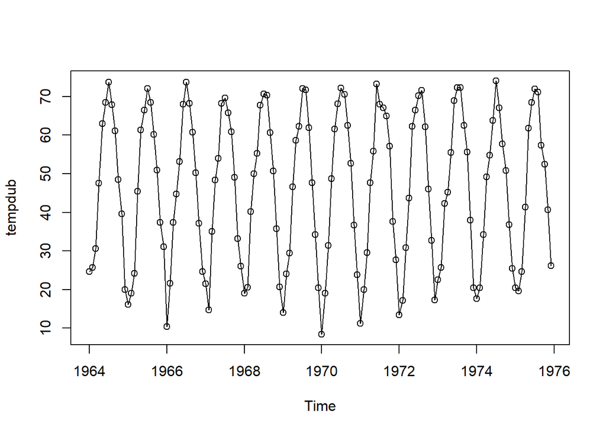

```r
plot(tempdub, type="o")
```

```r
#plot(ts(fitted(model4tempcos),freq=12,start=c(1964,1)),ylab='Temperatur',type='l',ylim=range(c(fitted(model4tempcos),tempdub)));
#points(tempdub)
```

Data fitted to the model. Notice the data points at the bottom of the chart (low temperatures) are not accounted for by the model.

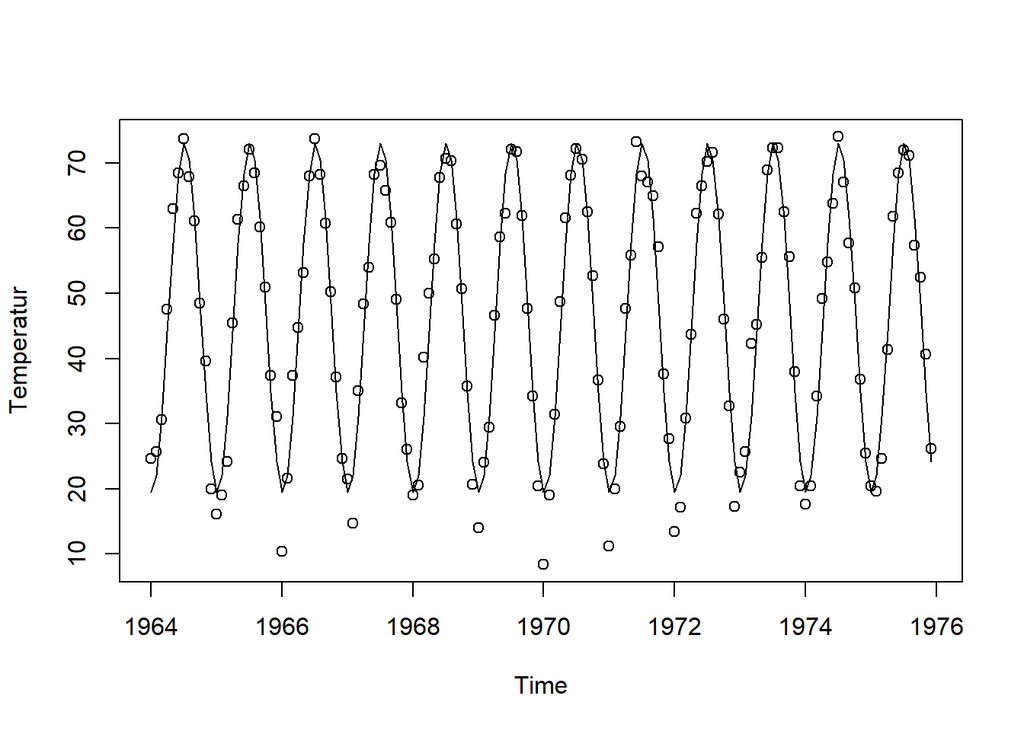

```r
plot(ts(fitted(model4tempcos),freq=12,start=c(1964,1)),ylab='Temperatur',type='l',ylim=range(c(fitted(model4tempcos),tempdub)));
points(tempdub)
```